# Module 7 - Regression with Resampling

Buckley

April 18, 2019

**Example:** The file posted on Canvas contains the finish times for a sample of runners in the 2015 Flying Pig Marathon. Also recorded was the length of time it took each runner to finish the first 13.1 miles of the course. Suppose we want to develop a model to predict finish time based upon split time.

```r
marathon = read.csv("flying pig.csv", header = T)

split = marathon$Split.13.1
finish = marathon$Finish.26.2
```

First, let’s visually inspect the relationship by creating a scatterplot:

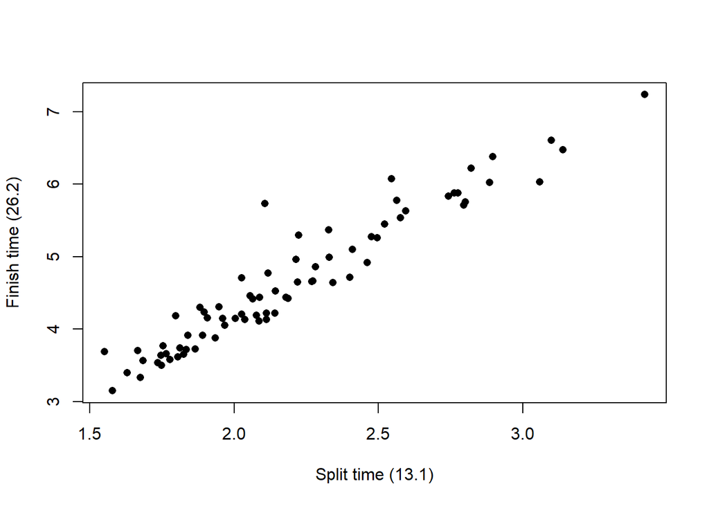

```r
plot(x = split, y = finish, pch=16, xlab = "Split time (13.1)", ylab = "Finish time (26.2)")
```

The scatterplot shows that as a runner’s split time increases their finish time also increases. The pattern observed suggests the relationship could be modeled with a linear function. The linear model is defined as $y = \beta_0 + \beta_1x + \epsilon$. $\beta_0$ and $\beta_1$ are parameters whose estimates can be obtained from the observed data. Because the model is not deterministic, an error term, $\epsilon$, is included. The errors are generally assumed to follow a normal distribution with mean 0 and standard deviation $\sigma_e$.

The model is fit to the data using the method of least squares - that is, the sum of the squared distance for each point to the line is minimized. To fit a linear model in R, the function lm is used. The input is the relationship to be modeled in the form y~x.

```r
summary(lm(finish~split))
```

```
##
## Call:
## lm(formula = finish ~ split)
##
## Residuals:
##      Min       1Q   Median       3Q      Max
## -0.45745 -0.18757 -0.03392  0.10279  1.27017
##
## Coefficients:
##              Estimate Std. Error t value Pr(>|t|)
## (Intercept) -0.007164   0.169597  -0.042    0.966
## split        2.123194   0.075859  27.989   <2e-16 ***
## ---
## Signif. codes:  0 '***' 0.001 '**' 0.01 '*' 0.05 '.' 0.1 ' ' 1
##
## Residual standard error: 0.273 on 73 degrees of freedom
## Multiple R-squared:  0.9148, Adjusted R-squared:  0.9136
## F-statistic: 783.4 on 1 and 73 DF,  p-value: < 2.2e-16
```

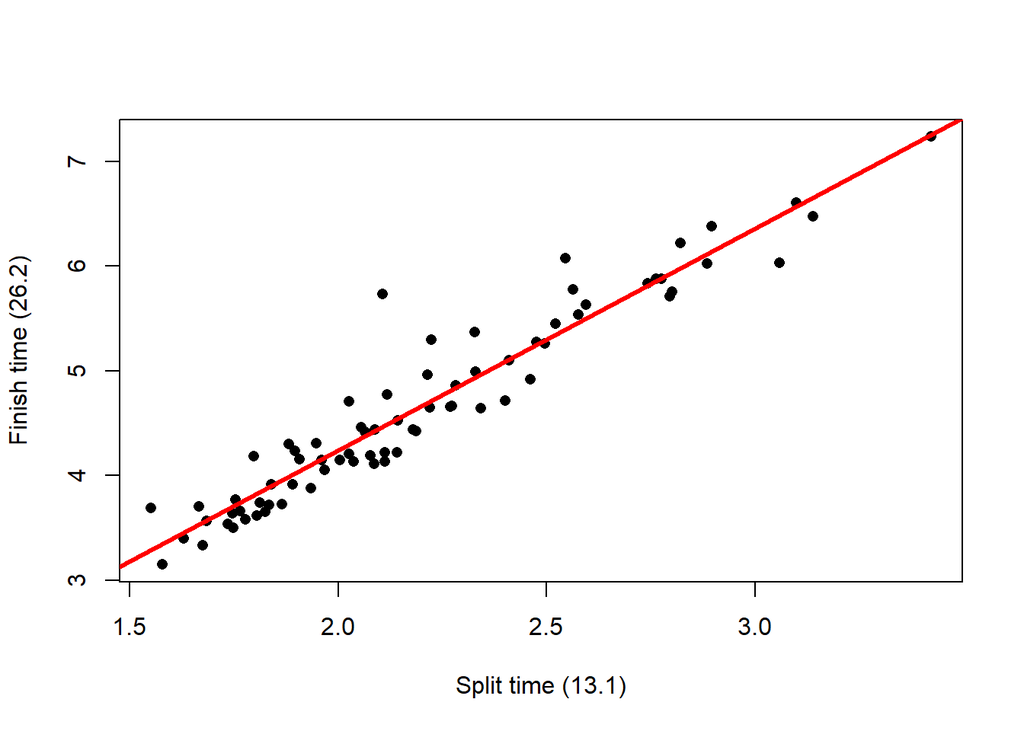

```r
# Add the line of best fit to the scatterplot
plot(x = split, y = finish, pch=16, xlab = "Split time (13.1)", ylab = "Finish time (26.2)")
abline(lm(finish~split), col="red", lwd=3)
```

In the regression output, we were given a p-value that tested the significance of the linear relationship (< 2e-16). If there is no relationship between the two variables, then average finish time would be the same regardless of split time. This corresponds to observing a line with a slope of 0 (a horizontal line). We can use a permutation test to determine if the linear relationship is significant. To do this, we’ll simulate the null distribution of the slope assuming there is no relationship between the variables.

## Permutation Test for the Slope

In a permutation test, we typically think about “shuffling” the data. What will it look like to shuffle our ordered pairs? If we assume there is no relationship between the two times, then any one finish time can be randomly assigned to a split time. To do this, we will “shuffle” the finish times, align them with the vector of split times, and fit the linear model. Let’s see what one iteration of this returns:

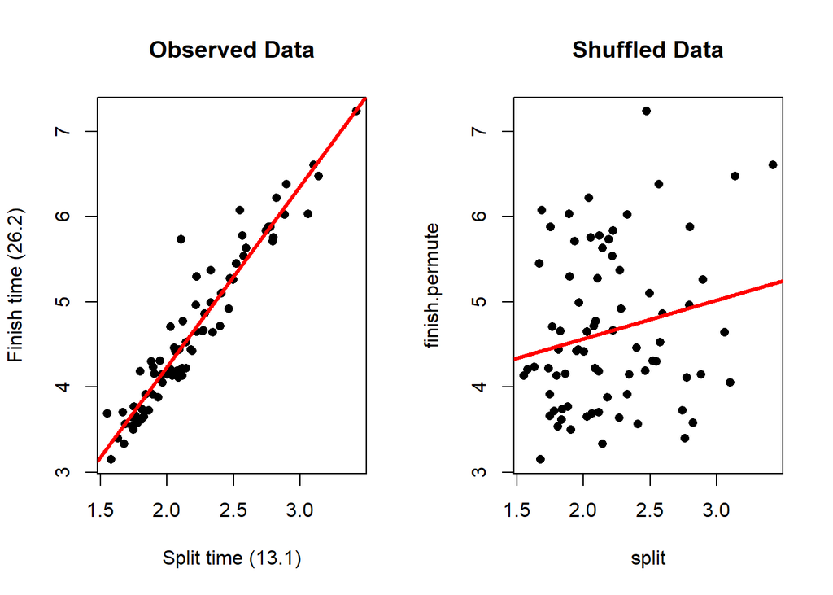

```r
finish.permute = sample(finish, length(finish))

par(mfrow=c(1,2))
#Line of best fit
plot(x=split, y=finish, pch=16, xlab = "Split time (13.1)", ylab = "Finish time (26.2)", main = "Observed Data")
abline(lm(finish~split), col="red", lwd=3)

plot(y=finish.permute, x=split, pch=16, main = "Shuffled Data")
abline(lm(finish.permute~split), col="red", lwd= 3)
```

Now let’s repeat this process to form the null distribution of the slope:

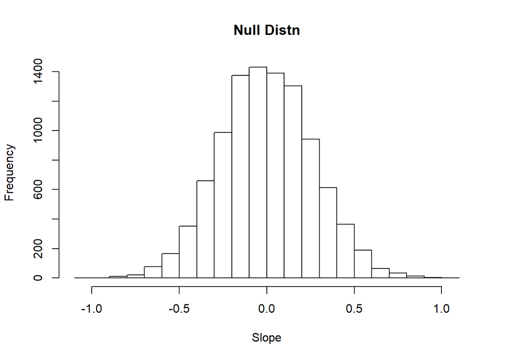

```r
null.slope = numeric(9999)

for (i in 1:9999){
  finish.permute = sample(finish, length(finish))

  null.slope[i] = summary(lm(finish.permute~split))$coefficients[2,1]
}

hist(null.slope, main = "Null Distn", xlab = "Slope")
```

$H_0: \beta_1 = 0$ (no relationship between times) $h_a: \beta_1 \ne 0$ (some relationship between times)

TS: slope = $b_1$ = 2.1231939

pvalue = 10^{-4}

Because the p-value is so small, there is significant evidence of a positive linear relationship between a runner’s split time and their finish time in the Flying Pig.

## Bootstrap Distn of the Slope

Notice in the output for the model, a standard error reported for the slope. This estimates variability in slope estimates from sample-to-sample of runners. We can use bootstrap techniques to find the distribution for the slope:

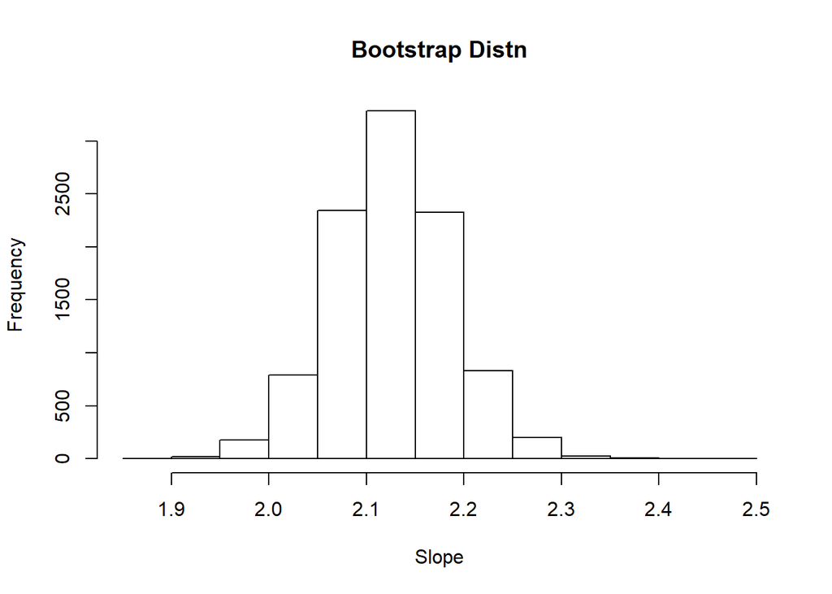

```r
boot.slope = numeric(10000)

for(i in 1:10000){
  index = sample(length(split), length(split), replace = T)
  boot.slope[i] = summary(lm(finish[index]~split[index]))$coefficients[2,1]
}

# Create a histogram of the bootstrap distribution
hist(boot.slope, main = "Bootstrap Distn", xlab = "Slope")
```

```r
mean(boot.slope)
```

```
## [1] 2.126243
```

```r
sd(boot.slope)
```

```
## [1] 0.06066076
```

Using the bootstrap distribution, the percentile interval for the slope can calculated:

```r
# lower_limit
quantile(boot.slope, probs = 0.025)
```

```
##     2.5%
## 2.008907
```

```r
# upper limit
quantile(boot.slope, probs = 0.975)
```

```
##    97.5%
## 2.248443
```

With 95% confidence, we estimate that for every additional hour it takes to complete 13.1 miles the final time it takes to complete the marathon is expected to increase by between 2.0089067 hours and 2.2484431 hours.

## Bootstraping the Residuals

In the linear model ($y = \beta_0 + \beta_1x + \epsilon$), the independent predictor variable (x) is often thought of as fixed, while the dependent response variable (y) is the one that varies. In our example, several individuals could all have the same split time of 2 hours, but each of their finish times will likely be different. The reason the response variable has variabiity is because of the random error term, $\epsilon$. Perhaps when we employ the bootstrap, we should take random sample, with replacement, of the residuals.

How would this approach work?

- Fit the linear model and store the residuals. The residuals measure the descrepancy between the observed y-values and the predicted y-values.
- Take a bootstrap sample from the residuals
- The resampled residuals could go with any one of the predicted values. Add the bootstrap residuals to the predicted y-values to obtain new bootstrapped response values.
- Fit a new linear model using the bootstrap-adjusted y-values and the predictor. Store the statistic of interest (in our case, we’ll first look at the slope).
- Repeat this process a total of 10,000 times.

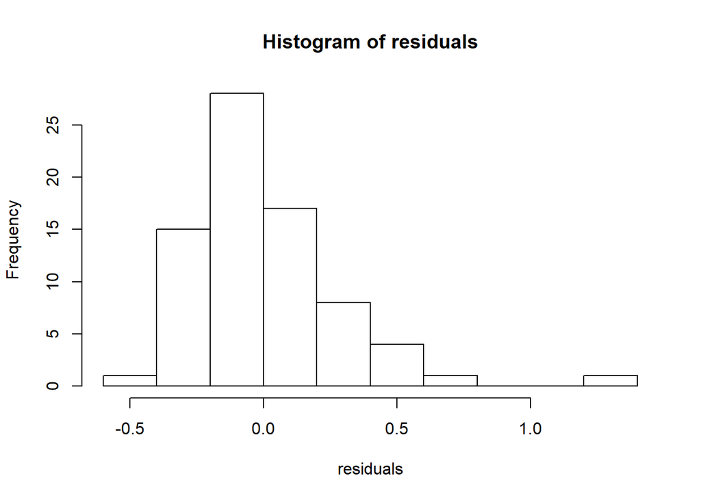

```r
# Store the residuals from the original linear model
residuals = lm(finish~split)$residuals
hist(residuals)
```

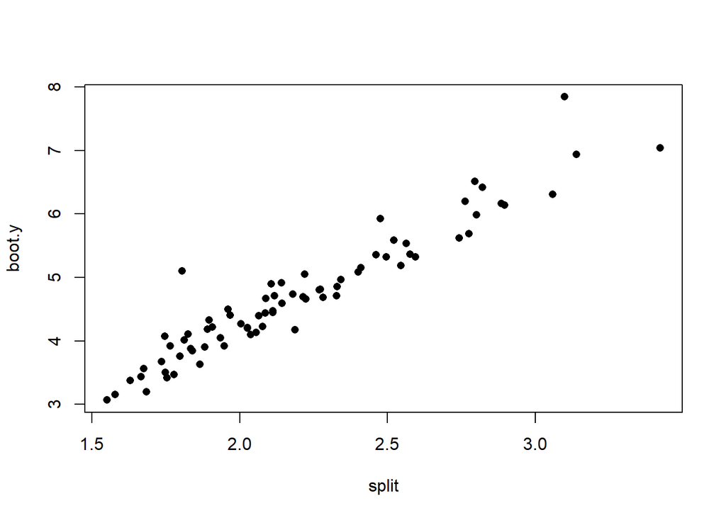

```r
#Bootstrap sample of the residuals
boot.residuals = sample(residuals, length(residuals), replace = T)

#Store the fitted values from the original linear model
fitted.y = lm(finish~split)$fitted.values

boot.y = fitted.y + boot.residuals
plot(x=split, y=boot.y, pch=16)
```

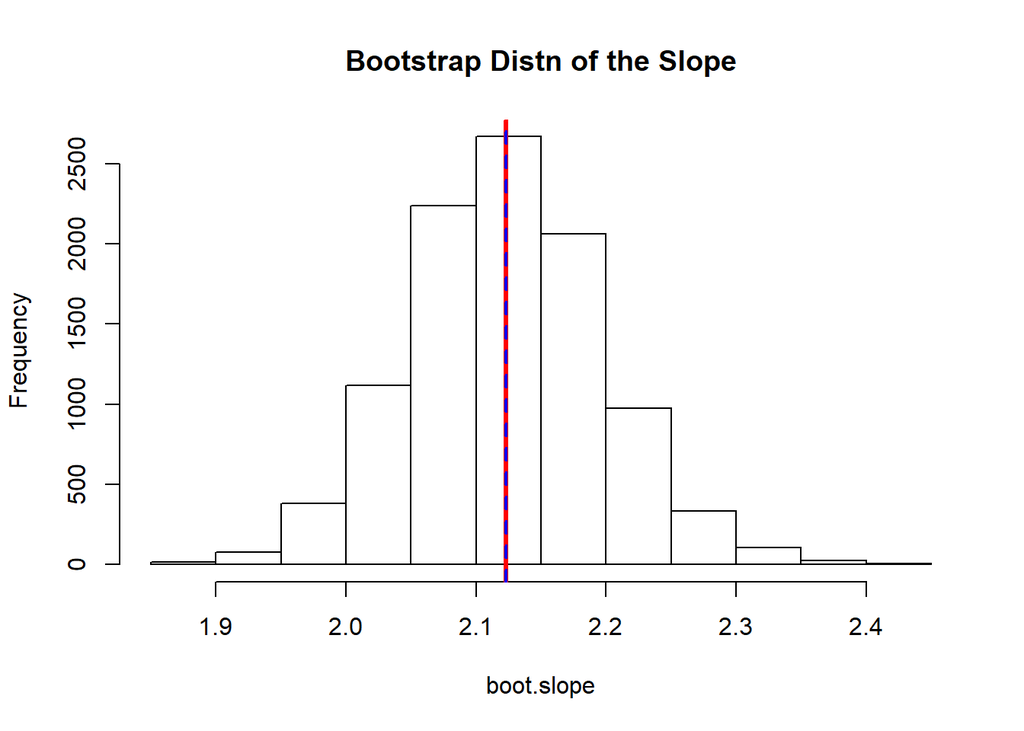

```r
boot.slope = numeric(10000)

for(i in 1:10000){
  boot.residuals = sample(residuals, length(residuals), replace = T)
  boot.y = fitted.y + boot.residuals
  boot.slope[i] = lm(boot.y~split)$coefficients[2]
}

hist(boot.slope, main = "Bootstrap Distn of the Slope")
abline(v=mean(boot.slope), col="red", lwd=3)
abline(v=lm(finish~split)$coefficients[2], col="blue", lty=2, lwd=2)
```

We can also ask R to do the prediction using the predict.lm function. In the function, the first input is the lm function with the relationship that is modeled. The second input is the value of the predictor - this must be stored as a data frame for the function to return predictions.

```r
new.obs = data.frame(split=2)
predict.lm(lm(finish~split), newdata = new.obs)
```

```
##        1
## 4.239224
```

What does this quantity acutally estimate? It estimates two pieces of information:

- Estimating the **mean** finish time for **all** runners with a split time of 2 hours in the Flying Pig. (Confidence Interval)
- The finish time for an **individaul** runner with a split time of 2 hours in the Flying Pig. (Prediction Interval)

The estimate provided from the fitted line is just a point estimate for these quantities - there is no confidence in the estimate. We can use bootstrap approaches to generate intervals.

First, let’s consider the confidence interval estimating the mean finish time for all runners with a split time of 2 hours:

```r
#Parametric Confidence Interval for the Mean
predict.lm(lm(finish~split), newdata = data.frame(split=2), interval = "confidence")
```

```
##        fit      lwr      upr
## 1 4.239224 4.169709 4.308739
```

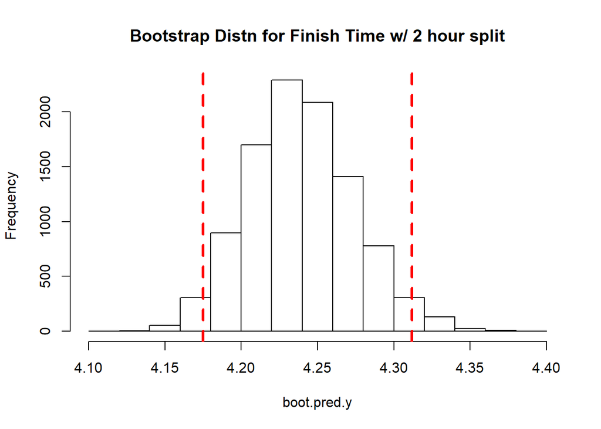

```r
#Bootstrap approaches
boot.pred.y = numeric(10000)

for(i in 1:10000){
  boot.residuals = sample(residuals, length(residuals), replace = T)
  boot.y = fitted.y + boot.residuals
  boot.pred.y[i] = predict.lm(lm(boot.y~split), newdata = data.frame(split=2))
}

hist(boot.pred.y, main = "Bootstrap Distn for Finish Time w/ 2 hour split")
abline(v=quantile(boot.pred.y, prob = c(0.025, 0.975)), col="red", lty=2, lwd=3)
```

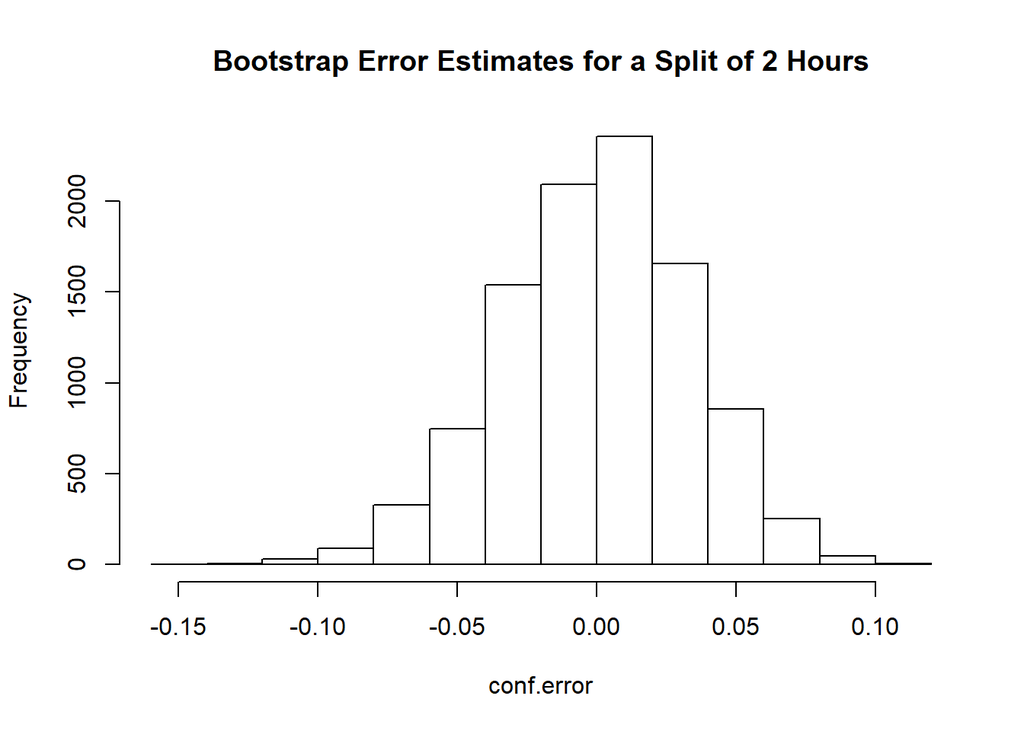

```r
#Bootstrap approaches - storing bootstrap predicted errors
conf.error = numeric(10000)

for(i in 1:10000){
  boot.residuals = sample(residuals, length(residuals), replace = T)
  boot.y = fitted.y + boot.residuals
  boot.pred.y[i] = predict.lm(lm(boot.y~split), newdata = data.frame(split=2))
  conf.error[i] = predict.lm(lm(finish~split), newdata = data.frame(split=2)) - boot.pred.y[i]
}

hist(conf.error, main = "Bootstrap Error Estimates for a Split of 2 Hours")
```

```r
# Confidence limits
pred.y = predict.lm(lm(finish~split), newdata = data.frame(split=2))

# Lower Limit
pred.y - quantile(conf.error, prob = 0.975)
```

```
##        1
## 4.176824
```

```r
# Upper Limit
pred.y + quantile(conf.error, prob = 0.975)
```

```
##        1
## 4.301624
```

```r
# Compare the bootstrap interval to the traditional parametric confidence interval

predict.lm(lm(finish~split), newdata = data.frame(split = 2), interval = "confidence")
```

```
##        fit      lwr      upr
## 1 4.239224 4.169709 4.308739
```

How does a prediction interval that predicts the response for a single observation differs from a confidence interval?

First, let’s compare the parametric intervals that are based on the t-distribution:

```r
# Parametric confidence interval
predict.lm(lm(finish~split), newdata = data.frame(split=2), interval = "confidence")
```

```
##        fit      lwr      upr
## 1 4.239224 4.169709 4.308739
```

```r
# Parametric prediction interval
predict.lm(lm(finish~split), newdata = data.frame(split=2), interval = "prediction")
```

```
##        fit      lwr      upr
## 1 4.239224 3.690669 4.787779
```

When we go calculate a predition interval, we are trying to find an interval that captures the response variable for an *individual* with some degree of confidence. Individual responses will always have more variability than the mean response for all individuals at a given response. The result is wider intervals.

We need a technique that allows us to incorporate additional variability into our bootstrap process.

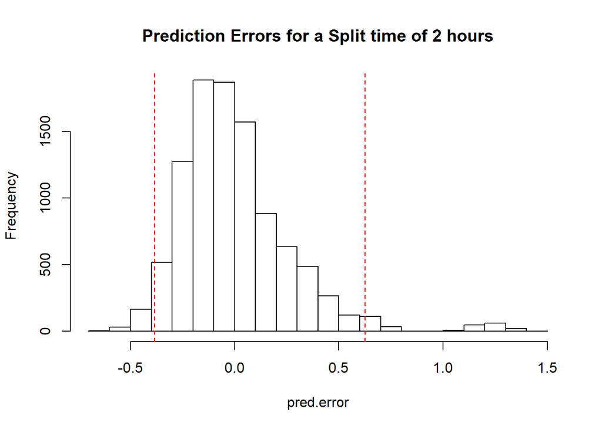

```r
# Create the prediction error distribution - how far is an individual's finish time from the predicted outcome?
pred.error = numeric(10000)

# Store the residual from the original model, as well as the fitted values from the original model
residuals = lm(finish~split)$residuals
fitted.y = lm(finish~split)$fitted.values

for (i in 1:10000){
  # Generate bootstraped y-hats
  boot.residuals = sample(residuals, length(residuals), replace = T)
  boot.y = fitted.y + boot.residuals

  # Now use the bootstrapped y-values to fit a new linear model & calculate the predicted value for a split time of 2 hours
  boot.pred.y = predict.lm(lm(boot.y~split), newdata = data.frame(split=2))

  # Generate a future value of y - original estimate from the line of best fit plus a random error from the bootstrapped regression model
  original.pred = predict.lm(lm(finish~split), newdata = data.frame(split=2))
  add.noise = sample(lm(boot.y~split)$residual, 1)
  future.y = original.pred + add.noise

  # For the prediction error, we want to know how far the future y value differed from the bootstrapped predicted y-value
  pred.error[i] = future.y - boot.pred.y

}

hist(pred.error, main = "Prediction Errors for a Split time of 2 hours")
abline(v=quantile(pred.error, probs = c(0.025, 0.975)), col="red", lty=2)
```

```r
#plot(y=boot.y, x=split, pch=16)
#abline(lm(boot.y~split), col="red")

# lower limit
original.pred - quantile(pred.error, probs = 0.975)
```

```
##        1
## 3.612664
```

```r
# upper limit
original.pred - quantile(pred.error, probs = 0.025)
```

```
##        1
## 4.623036
```

With 95% confidence, we predict an individual running the Flying Pig who has a split time of 2 hours will finish the marathon with a time between 3.6126644 hours and 4.6230357 hours.

## Example

The dataset posted on Canvas contains the number of classes missed (out of 37) and the final course grade for a sample of STA 205 students. We would like to develop a model which can be used to predict course grade from attendance.

- Create a scatterplot of the relationship of interest and find the correlation (using the cor() function in R). You’ll notice that several students seem to have missed all the classes. Attendance was tracked via a clicker, and these students chose to not purchase a clicker. Remove them from the dataset and regenerate the scatterplot and correlation. What effect did removing this students have?

```r
course.grades = read.csv("course grades.csv", header = T)

#plot(x=course.grades$Classes.Missed, y = course.grades$Average, pch=16)

cor(course.grades$Classes.Missed, course.grades$Average)
```

```
## [1] -0.6399213
```

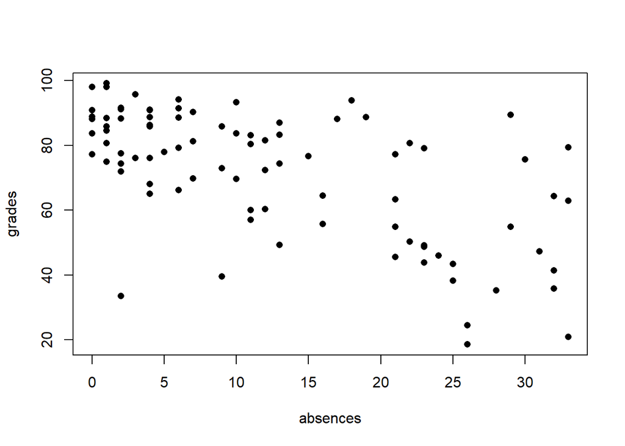

```r
# Restrict the dataset to only include students with recorded attendance (i.e. no one with 37 absences)

absences = subset(course.grades, subset = Classes.Missed < 37, select = Classes.Missed, drop = T)
grades = subset(course.grades, subset = Classes.Missed < 37, select = Average, drop = T)

plot(x=absences, y=grades, pch=16)
```

```r
cor(absences, grades)
```

```
## [1] -0.6228297
```

For the remaining questions, work on the dataset with the removed students who did not purchase a clicker.

- Fit the regression model to the data collected. What is the estimated regression equation?

```r
course.grades.fit = lm(grades~absences)
course.grades.fit$coefficients
```

```
## (Intercept)    absences
##   86.281250   -1.175901
```

```
The estimated regression equation for predicting grades is: Grades = 86.2812497 -1.175901
```

- Use a permutation test to determine if the linear relationship between the variables is significant.

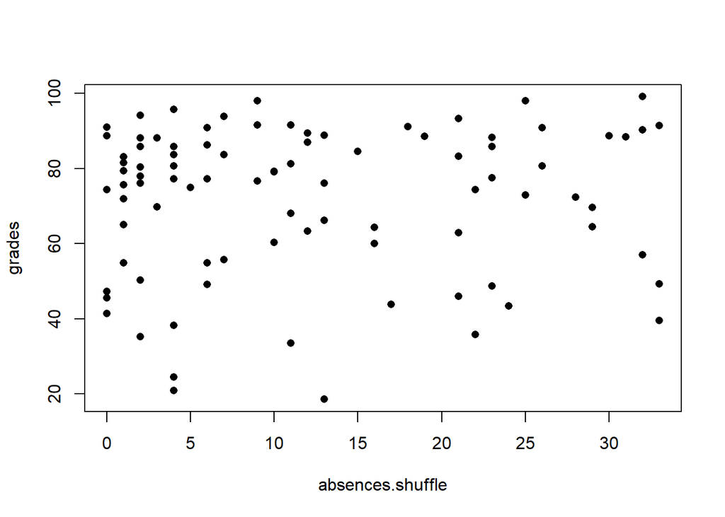

```r
null.slope <- numeric(9999)

for(i in 1:9999){
  absences.shuffle <- sample(absences, length(absences))
  null.slope[i] <- lm(grades~absences.shuffle)$coefficients[2]
}

plot(x=absences.shuffle, y=grades, pch=16)
```

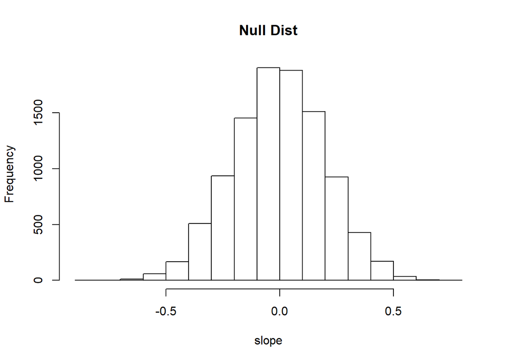

```r
hist(null.slope, main="Null Dist", xlab="slope")
```

```r
# Take the observed slope (-1.1759) -- how many of the null distribution slopes were more extreme than that value
```

$H_0: \beta_1 = 0$ (There is not a linear relationship)

$H_a: \beta_1 \ne 0$ (There is a linear relationship)

TS: $b_1$ =-1.175901 (The second coefficient for the linear model is slope)

(The null distributions gives you an idea of how much of a difference there is from one set of students to another set of students) The null distribution of the slope is how you get the p-value (Find values more extreme than the observed value)

p-value = $\frac{\text{# of null slopes < -1.18} + \text{# of null slopes > 1.18}+1}{9999+1}$ = 10^{-4}

Because the p-value is so small, there is significant evidence of a negative linear relationship between course average & absences. As the number of absences increases, the expected course average (grade in reported as a percent) decreases.

- **Find a 95% bootstrap percentile interval for the intercept by bootstrapping the residuals of the model (you do not have to using smoothing). Interpret the interval.**

Bootstrap the residuals (Find all the vertical distances and resmaple from those - one residual could just as easily go with another individual)

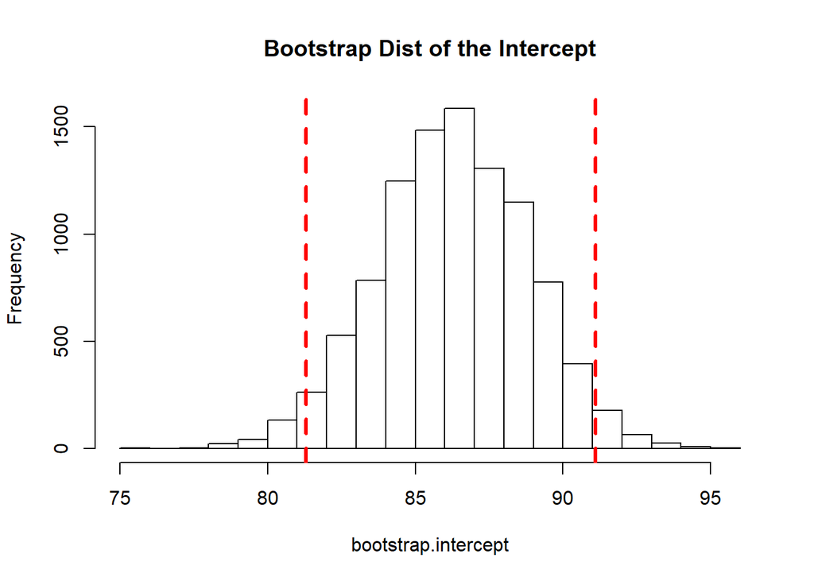

```r
bootstrap.intercept <- numeric(10000)

residuals <- lm(grades~absences)$residuals
fitted.y <- lm(grades~absences)$fitted.values #values the regression line predicted

for(i in 1:10000){
  bootstrap.residuals <- sample(residuals, length(residuals), replace=T)
  bootstrap.intercept[i] <- lm((fitted.y+bootstrap.residuals)~absences)$coefficients[1]
}

hist(bootstrap.intercept, main="Bootstrap Dist of the Intercept")
abline(v=quantile(bootstrap.intercept, probs=c(0.025,0.975)), col="red", lwd=3, lty=2)
```

With 95% confidence, we estimate the **mean course average grade** (recorded as a percent) for students with no absences falls betwreen 81.2960584 and 91.1103247(Confidence interval)

- **The interval found in the previous part is equivalent to a confidence interval estimating the mean grade for a student who misses 0 classes. If an individual student who misses 0 classes is interested in predicting their grade, find the interval which would provide this estimate.**

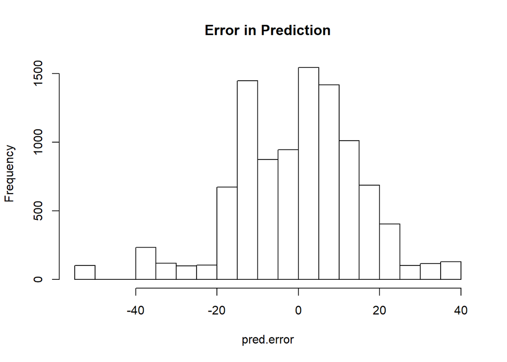

```r
pred.error <- numeric(10000)

residuals <- lm(grades~absences)$residuals
fitted.y <- lm(grades~absences)$fitted.values

original.pred <- predict.lm(lm(grades~absences), newdata=data.frame(absences=0)) #Technically this is just the intercept for this model. We just want this to be code that can support changing numbers

for(i in 1:10000){
  # Generate bootstrapped residuals
  boot.residuals <- sample(residuals, length(residuals), replace=T)

  # Bootstrapped y-values from the residuals
  boot.y <- fitted.y + residuals

  # Now use the bootstrapped y-values to generate a new linear model and calculate the prediction for 0 absences
  boot.pred.y <- predict.lm(   lm(boot.y~absences), newdata =data.frame(absences=0)   )

  # Generate a future value of y-original estimate from the line of best fit plus a random error from the bootstrapped regression model
  add.noise <- sample(lm(boot.y~absences)$residuals, 1)
  future.y <- original.pred + add.noise
  pred.error[i] <- future.y - boot.pred.y #How far off is the future.y from what the model told us we should have? -- prediction error

}

hist(pred.error, main="Error in Prediction")
```

```r
l.limit <- original.pred - quantile(pred.error, probs=0.975) # lower limit

u.limit <- original.pred - quantile(pred.error, probs=0.025) # upper limit

l.limit
```

```
##        1
## 57.52471
```

```r
u.limit
```

```
##        1
## 122.3653
```

```r
# "True" parametric interval
predict.lm(lm(grades~absences), newdata=data.frame(absences=0), interval="prediction")
```

```
##        fit      lwr      upr
## 1 86.28125 55.02318 117.5393
```

Pick off the 2.5% and 97.5% quantiles